# PRACTICA 2. ANÁLISIS DE LA CALIDAD DE VINOS ROJOS

Rubén Gómez Marquez y Andrés Felipe Bello Zapata

30/5/2020

# 1. DESCRIPCIÓN DEL DATASET

En esta primera parte visualizaremos el dataset y describiremos las variables que lo componen, tratando de entender que preguntas o problemas pueden ayudarnos a responder.

```r
#CARGA DEL ARCHIVO
redwine<-read.csv("redwine.csv",sep=",",na.string="NA",header = TRUE)
#PRIMERA VISUALIZACIÓN
head(redwine, max(10))
```

```
##    fixed.acidity volatile.acidity citric.acid residual.sugar chlorides
## 1            7.4             0.70        0.00            1.9     0.076
## 2            7.8             0.88        0.00            2.6     0.098
## 3            7.8             0.76        0.04            2.3     0.092
## 4           11.2             0.28        0.56            1.9     0.075
## 5            7.4             0.70        0.00            1.9     0.076
## 6            7.4             0.66        0.00            1.8     0.075
## 7            7.9             0.60        0.06            1.6     0.069
## 8            7.3             0.65        0.00            1.2     0.065
## 9            7.8             0.58        0.02            2.0     0.073
## 10           7.5             0.50        0.36            6.1     0.071
##    free.sulfur.dioxide total.sulfur.dioxide density   pH sulphates alcohol
## 1                   11                   34  0.9978 3.51      0.56     9.4
## 2                   25                   67  0.9968 3.20      0.68     9.8
## 3                   15                   54  0.9970 3.26      0.65     9.8
```

[output cut: 18 more lines]

```r
#ESTRUCTURA DEL DATASET
str(redwine)
```

```
## 'data.frame':    1599 obs. of  12 variables:
##  $ fixed.acidity       : num  7.4 7.8 7.8 11.2 7.4 7.4 7.9 7.3 7.8 7.5 ...
##  $ volatile.acidity    : num  0.7 0.88 0.76 0.28 0.7 0.66 0.6 0.65 0.58 0.5 ...
##  $ citric.acid         : num  0 0 0.04 0.56 0 0 0.06 0 0.02 0.36 ...
##  $ residual.sugar      : num  1.9 2.6 2.3 1.9 1.9 1.8 1.6 1.2 2 6.1 ...
##  $ chlorides           : num  0.076 0.098 0.092 0.075 0.076 0.075 0.069 0.065 0.073 0.071 ...
##  $ free.sulfur.dioxide : num  11 25 15 17 11 13 15 15 9 17 ...
##  $ total.sulfur.dioxide: num  34 67 54 60 34 40 59 21 18 102 ...
##  $ density             : num  0.998 0.997 0.997 0.998 0.998 ...
##  $ pH                  : num  3.51 3.2 3.26 3.16 3.51 3.51 3.3 3.39 3.36 3.35 ...
##  $ sulphates           : num  0.56 0.68 0.65 0.58 0.56 0.56 0.46 0.47 0.57 0.8 ...
##  $ alcohol             : num  9.4 9.8 9.8 9.8 9.4 9.4 9.4 10 9.5 10.5 ...
##  $ quality             : int  5 5 5 6 5 5 5 7 7 5 ...
```

## 1.1 Descripción de los atributos

En este data set se describen las propiedades químicas de un conjunto de vinos rojos procedentes del norte de Portugal. Estos vinos están clasificados por puntuaciones basadas en la opinión personal.

Todos los atributos del dataset son variables numéricas y continuas, excepto quality que es una variable tipo int, es decir, numérica discreta (enteros):

fixed.acidity: acidez fija. (ácido tartárico - g / dm^3) volatile.acidity: acidez volatil. (ácido acético - g / dm^3) citric.acid: acidez citrica.(g / dm^3) residual.sugar:azucar residual.(g / dm^3) chlorides:cloruros.(cloruro sódico - g / dm^3 ) free.sulfur.dioxide:dióxido de azufre libre. (mg / dm^3) total.sulfur.dioxide:dióxido de azufre total.(mg / dm^3) density:densidad.(g / cm^3) pH:ph. sulphates:sulfatos.(sulfato potásico - g / dm3) alcohol:alcohol.(% por volumen) quality: calidad del vino según una opinión personal 0-10.

## 1.2 Motivaciones

Este dataset puede ayudarnos a comprender, desde un punto de vista químico, que propiedades debe tener un vino para que guste a los consumidores. Preguntas que siguen la linea de: ¿qué grado de alcohol prefieren los consumidores?. Y de está forma con cualquier propiedad química del vino.

# 2. INTEGRACIÓN Y SELECCIÓN DE LOS DATOS DE INTERÉS A ANALIZAR

En esta etapa no haremos ningún tipo de integración de datos ya que solo tenemos este dataset con el cual trabajar.

## 2.1 Comprobación de la normalidad y homogeneidad de la varianza.

Previo a realizar la reducción de dimensionalidad es necesario verificar si cada una de las columnas presenta una distribución normal. Lo anterior con el fin de determinar que modelo estadístico implementar. Para ello se emplea el test Shapiro que, determina si una columna tiene una distribución normal basado en el valor de la variable p, la cual cuando asume valores superiores a 0.05 permite confirmar la hipotesis nula, concluyendo que los datos presentan una distribución normal.

Test Shapiro para la columna fixed acidity

```r
shapiro.test(redwine$fixed.acidity)
```

```
##
##  Shapiro-Wilk normality test
##
## data:  redwine$fixed.acidity
## W = 0.94203, p-value < 2.2e-16
```

Test Shapiro para la columna volatile acidity

```r
shapiro.test(redwine$volatile.acidity)
```

```
##
##  Shapiro-Wilk normality test
##
## data:  redwine$volatile.acidity
## W = 0.97434, p-value = 2.693e-16
```

Test Shapiro para la columna citric acid

```r
shapiro.test(redwine$citric.acid)
```

```
##
##  Shapiro-Wilk normality test
##
## data:  redwine$citric.acid
## W = 0.95529, p-value < 2.2e-16
```

Test Shapiro para la columna residual sugar

```r
shapiro.test(redwine$residual.sugar)
```

```
##
##  Shapiro-Wilk normality test
##
## data:  redwine$residual.sugar
## W = 0.56608, p-value < 2.2e-16
```

Test Shapiro para la columna chlorides

```r
shapiro.test(redwine$chlorides)
```

```
##
##  Shapiro-Wilk normality test
##
## data:  redwine$chlorides
## W = 0.48425, p-value < 2.2e-16
```

Test Shapiro para la columna total sulfur dioxide

```r
shapiro.test(redwine$total.sulfur.dioxide)
```

```
##
##  Shapiro-Wilk normality test
##
## data:  redwine$total.sulfur.dioxide
## W = 0.87322, p-value < 2.2e-16
```

Test Shapiro para la columna density

```r
shapiro.test(redwine$density)
```

```
##
##  Shapiro-Wilk normality test
##
## data:  redwine$density
## W = 0.99087, p-value = 1.936e-08
```

Test Shapiro para la columna ph

```r
shapiro.test(redwine$pH)
```

```
##
##  Shapiro-Wilk normality test
##
## data:  redwine$pH
## W = 0.99349, p-value = 1.712e-06
```

Test Shapiro para la columna sulphates

```r
shapiro.test(redwine$sulphates)
```

```
##
##  Shapiro-Wilk normality test
##
## data:  redwine$sulphates
## W = 0.83304, p-value < 2.2e-16
```

Test Shapiro para la columna alcohol

```r
shapiro.test(redwine$alcohol)
```

```
##
##  Shapiro-Wilk normality test
##
## data:  redwine$alcohol
## W = 0.92884, p-value < 2.2e-16
```

Test Shapiro para la columna quality

```r
shapiro.test(redwine$quality)
```

```
##
##  Shapiro-Wilk normality test
##
## data:  redwine$quality
## W = 0.85759, p-value < 2.2e-16
```

Se evidencia que todas las columnas tienen valores inferiores a 0.05 por lo tanto se rechaza la hipotesis nula y se confirma que nignuna las columnas relacionadas presentan una distribución normal.

El metodo rotation permite identificar que efectivamente se genera un componente principal por cada una de las variables, relacionando en cada una de ellas el porcentaje de participación que tendría cada una de las variables.

```r
pca <- prcomp(redwine, scale = TRUE)
pca$rotation
```

```
##                               PC1          PC2         PC3          PC4
## fixed.acidity         0.487883358 -0.004173212  0.16482854  0.231098077
## volatile.acidity     -0.265128984  0.338967858  0.22708884 -0.041858245
## citric.acid           0.473335467 -0.137358104 -0.10022856  0.056735802
## residual.sugar        0.139154423  0.167736336 -0.24362014  0.383037581
## chlorides             0.197426792  0.189788185  0.02660785 -0.654777820
## free.sulfur.dioxide  -0.045880713  0.259483136 -0.61611132  0.033711483
## total.sulfur.dioxide  0.004066746  0.363971374 -0.54073214  0.028459726
## density               0.370301191  0.330780789  0.16872267  0.200693412
## pH                   -0.432720849 -0.065440145 -0.06977056  0.005466181
## sulphates             0.254535354 -0.109333620 -0.21291324 -0.560502367
## alcohol              -0.073176777 -0.502708647 -0.22497138  0.091701428
## quality               0.112488776 -0.473166214 -0.22336929  0.036669226
##                              PC5         PC6        PC7         PC8         PC9
## fixed.acidity        -0.07877938  0.05553130 -0.3072150  0.20052866 -0.17457815
## volatile.acidity      0.29937933  0.29728700 -0.6262337  0.14612614 -0.06022334
## citric.acid          -0.12014871  0.13663328  0.2441486  0.29633271 -0.22097505
## residual.sugar        0.70936319  0.10931059  0.2838543 -0.17062614  0.27818728
## chlorides             0.26623723  0.33733656  0.2305470 -0.18692254 -0.41993639
## free.sulfur.dioxide  -0.15941286 -0.04264807 -0.1382604 -0.01935607 -0.31800012
## total.sulfur.dioxide -0.21845284  0.11595360 -0.1102087  0.08989655  0.12182276
## density               0.20879298 -0.42566742 -0.1225465  0.07950023 -0.24907449
## pH                    0.25764682 -0.48035396  0.1856917  0.31469303 -0.46191598
## sulphates             0.21483493 -0.40374303 -0.2334021  0.27549158  0.45268884
## alcohol               0.25972635  0.39217625 -0.1217188  0.47118865 -0.09652795
## quality               0.13758414 -0.14183046 -0.4123879 -0.61224719 -0.24024309
##                              PC10         PC11         PC12
## fixed.acidity         0.182956014 -0.256437921  0.638579761
## volatile.acidity     -0.155105626  0.377161229  0.004661681
## citric.acid          -0.346085556  0.624327833 -0.070036908
## residual.sugar        0.052236558  0.088077871  0.183646374
## chlorides             0.003862734 -0.208616670  0.053931176
## free.sulfur.dioxide   0.585388580  0.237933171 -0.051921666
## total.sulfur.dioxide -0.589188239 -0.355046842  0.069792953
## density              -0.043538098 -0.231453058 -0.566644992
## pH                   -0.207609889 -0.005599072  0.341230056
## sulphates             0.071918570  0.097637028  0.067792979
## alcohol               0.110605247 -0.319948696 -0.317640325
## quality              -0.260239788  0.052465707  0.008470476
```

Una vez se visualizan los componentes principales se procede a verificar la desviación estandar con el fin de identificar que efectivamente cada una de las columnas del PCA presenta una desviación estandar menor. Lo anterior indica que el modelo es aplicado de manera correcta abarcando en cada componente prinicipal una mayor cantidad de datos.

```r
print(pca$sdev)
```

```
##  [1] 1.7666827 1.4972916 1.2972739 1.1022799 0.9865412 0.8139977 0.7863319
##  [8] 0.7112472 0.6413326 0.5726425 0.4245216 0.2439629
```

Finalmente se analiza la proporción acumulada con el fin de determinar el nivel de precisión que nos daria el empleo de cada uno de los componentes principales y determinar si es viable reducir la dimensionalidad de los datos.

```r
summary(pca)
```

```
## Importance of components:
##                           PC1    PC2    PC3    PC4     PC5     PC6     PC7
## Standard deviation     1.7667 1.4973 1.2973 1.1023 0.98654 0.81400 0.78633
## Proportion of Variance 0.2601 0.1868 0.1402 0.1013 0.08111 0.05522 0.05153
## Cumulative Proportion  0.2601 0.4469 0.5872 0.6884 0.76952 0.82474 0.87626
##                            PC8     PC9    PC10    PC11    PC12
## Standard deviation     0.71125 0.64133 0.57264 0.42452 0.24396
## Proportion of Variance 0.04216 0.03428 0.02733 0.01502 0.00496
## Cumulative Proportion  0.91842 0.95270 0.98002 0.99504 1.00000
```

Del anterior análisis estadístico se logra identificar que mediante el uso de Componente Principales, es posible eliminar una o máximo 2 columnas de la base de datos, manteniendo un nivel presición del 98%, siendo esta una reducción no tan cosiderable, por lo tanto se toma la determinación de analizar el impacto que tiene cada una de las variables independientes en la variable dependiente de QUALITY ques es finalmente la que se desea analizar. De esta forma es mas viable descartar las variables que no influyen de manera considerable en la calidad del vino.

## 2.2 Selección de datos

Por tanto, para realizar la selección de los datos analizaremos la correlación entre las variables con el fin de ver cuales están relacionadas entre sí.De esta forma podremos observar que variables mantienen una mayor relación con la variable calidad, que es la variable que nos interesa analizar y podremos hacer una reducción de variables, quedandonos unicamente con las variables que más contribuyan.

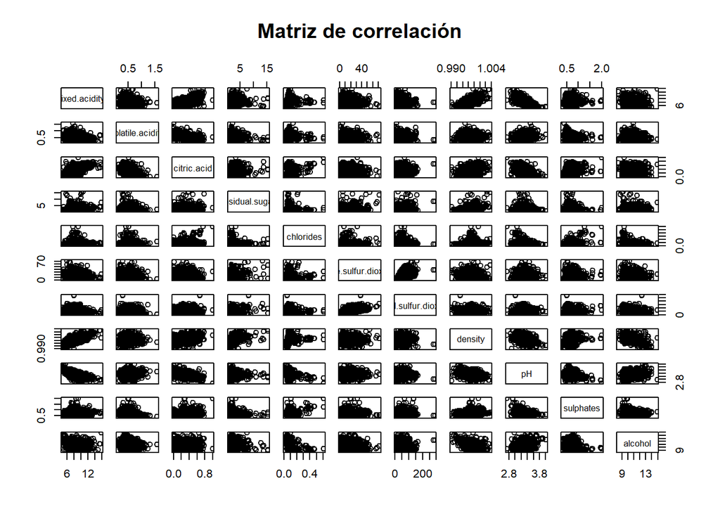

```r
#Mostramos la matriz de dispersión para visualizar la linealidad entre las variables
pairs(fixed.acidity ~ volatile.acidity + citric.acid + residual.sugar + chlorides + free.sulfur.dioxide + total.sulfur.dioxide + density + pH + sulphates + alcohol, data = redwine, main="Matriz de correlación", size= 20)
```

```r
#Mostramos la matriz de correlaciones que nos indica las relaciones entre las diferentes variables.
round(cor(redwine),2)
```

```
##                      fixed.acidity volatile.acidity citric.acid residual.sugar
## fixed.acidity                 1.00            -0.26        0.67           0.11
## volatile.acidity             -0.26             1.00       -0.55           0.00
## citric.acid                   0.67            -0.55        1.00           0.14
## residual.sugar                0.11             0.00        0.14           1.00
## chlorides                     0.09             0.06        0.20           0.06
## free.sulfur.dioxide          -0.15            -0.01       -0.06           0.19
## total.sulfur.dioxide         -0.11             0.08        0.04           0.20
## density                       0.67             0.02        0.36           0.36
## pH                           -0.68             0.23       -0.54          -0.09
## sulphates                     0.18            -0.26        0.31           0.01
## alcohol                      -0.06            -0.20        0.11           0.04
## quality                       0.12            -0.39        0.23           0.01
##                      chlorides free.sulfur.dioxide total.sulfur.dioxide density
## fixed.acidity             0.09               -0.15                -0.11    0.67
## volatile.acidity          0.06               -0.01                 0.08    0.02
## citric.acid               0.20               -0.06                 0.04    0.36
## residual.sugar            0.06                0.19                 0.20    0.36
## chlorides                 1.00                0.01                 0.05    0.20
## free.sulfur.dioxide       0.01                1.00                 0.67   -0.02
## total.sulfur.dioxide      0.05                0.67                 1.00    0.07
## density                   0.20               -0.02                 0.07    1.00
## pH                       -0.27                0.07                -0.07   -0.34
## sulphates                 0.37                0.05                 0.04    0.15
## alcohol                  -0.22               -0.07                -0.21   -0.50
## quality                  -0.13               -0.05                -0.19   -0.17
##                         pH sulphates alcohol quality
## fixed.acidity        -0.68      0.18   -0.06    0.12
## volatile.acidity      0.23     -0.26   -0.20   -0.39
## citric.acid          -0.54      0.31    0.11    0.23
## residual.sugar       -0.09      0.01    0.04    0.01
## chlorides            -0.27      0.37   -0.22   -0.13
## free.sulfur.dioxide   0.07      0.05   -0.07   -0.05
## total.sulfur.dioxide -0.07      0.04   -0.21   -0.19
## density              -0.34      0.15   -0.50   -0.17
## pH                    1.00     -0.20    0.21   -0.06
## sulphates            -0.20      1.00    0.09    0.25
## alcohol               0.21      0.09    1.00    0.48
## quality              -0.06      0.25    0.48    1.00
```

Nos fijamos en la variable que realmente nos interesa para saber que vinos son los mejor valorados, que es la calidad. Esta variable presenta una mayor correlación con la acidez volatil y cítrica, los sulfatos y en mayor medida con el alcohol. Por tanto, estas serán las variables que analizaremos.

```r
#Dividimos el dataset en 2. Por una parte las variables que queremos analizar y por otra parte la variable predictora o analítica (quality) que nos servirá para analizar los vinos.
variables <- redwine[c(2,3,10,11)]
calidad<-redwine[12]
```

# 3. LIMPIEZA DE DATOS

## 3.1 Ceros o elementos vacíos.

Analizaremos si el dataset contiene ceros o elementos vacios.

```r
summary(variables)
```

```
##  volatile.acidity  citric.acid      sulphates         alcohol
##  Min.   :0.1200   Min.   :0.000   Min.   :0.3300   Min.   : 8.40
##  1st Qu.:0.3900   1st Qu.:0.090   1st Qu.:0.5500   1st Qu.: 9.50
##  Median :0.5200   Median :0.260   Median :0.6200   Median :10.20
##  Mean   :0.5278   Mean   :0.271   Mean   :0.6581   Mean   :10.42
##  3rd Qu.:0.6400   3rd Qu.:0.420   3rd Qu.:0.7300   3rd Qu.:11.10
##  Max.   :1.5800   Max.   :1.000   Max.   :2.0000   Max.   :14.90
```

```r
summary(calidad)
```

```
##     quality
##  Min.   :3.000
##  1st Qu.:5.000
##  Median :6.000
##  Mean   :5.636
##  3rd Qu.:6.000
##  Max.   :8.000
```

Podemos ver con la función summary un resumen de las variables que queremos analizar. Observamos que no hay elementos vacios (NA’s) y a su vez que tenemos ceros en la variable citric.acid.

En caso de encontrarnos con elementos vacíos, se puede proceder de varias formas:

- Eliminando las filas que contienen los valores vacíos. Esto puede ser útil y ahorrarnos bastante trabajo pero solo si tenemos muchas filas y pocos elementos vacíos, de forma que no alteremos la estadística.
- Sustituir los valores vacíos por nulos (NA).
- Aproximarlos por métodos de estadísticos, por ejemplo, sustituirlos por la media. Hay otros métodos como el método de los k vecinos más próximos (k-neighbors), que tratan de rellenar el valor perdido en función de los valores que se encuentran más cerca en el dataset.

Si nos encontrásemos con ceros, habría que interpretar para cada variable si tiene sentido o no. En nuestro caso la variable que indica el ácido cítrico es numérica y continua por lo que en este aspecto si que podríamos tener ceros. Por otra parte en https://www.lavinoteca.info/que-es-la-acidez nos indican que el ácido cítrico es poco abundante en la uva y que despues de la fermentación este desaparece, por tanto si tiene sentido encontrarnos ceros en esta variable.

## 3.2 Identificación y tratamiento de valores extremos.

Analizaremos las variables cuantitativas para detectar valores extremos, mediante la generación de diagramas de caja y la función boxplot.stats.

### ÁCIDO VOLATIL (http://urbinavinos.blogspot.com/2011/08/acidez-volatil-en-vinos.html)

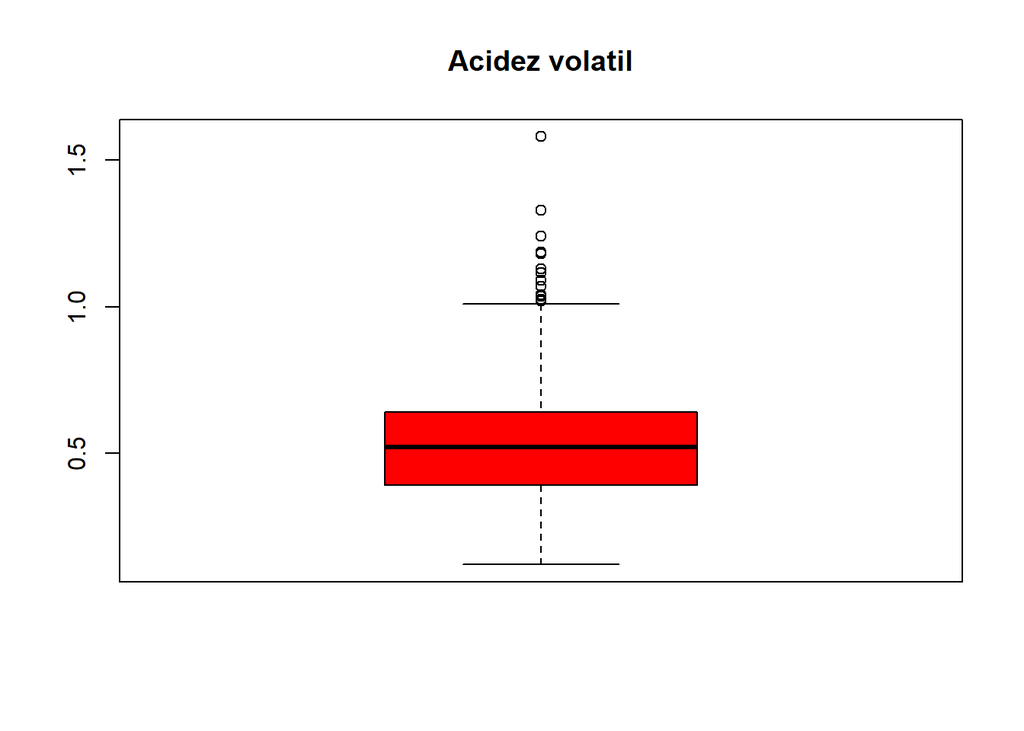

```r
#Boxplot para obtener los valores extremos
boxplot(variables$volatile.acidity,main="Acidez volatil",col="red")
```

```r
boxplot.stats(variables$volatile.acidity)$out
```

```
##  [1] 1.130 1.020 1.070 1.330 1.330 1.040 1.090 1.040 1.240 1.185 1.020 1.035
## [13] 1.025 1.115 1.020 1.020 1.580 1.180 1.040
```

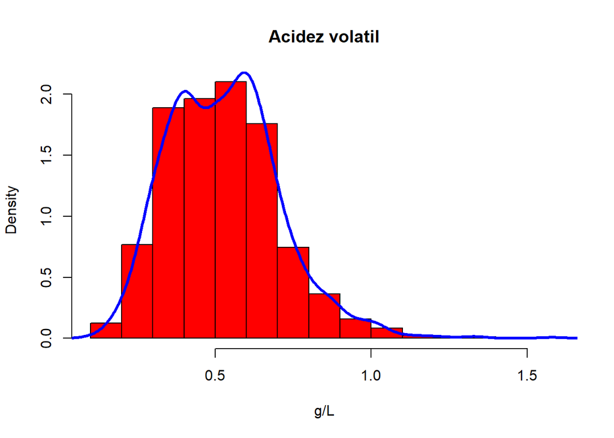

```r
#Diagrama de densidad para observar la distribución
den.vol<-density(variables$volatile.acidity)
hist(variables$volatile.acidity, main="Acidez volatil", col="red", freq = FALSE, xlab="g/L")
lines(den.vol,col="blue",lwd=3)
```

### ÁCIDO CÍTRICO (https://www.vinosycavasonline.es/los-aacidos-del-vino.-quae-son-y-caomo-se-forman.)

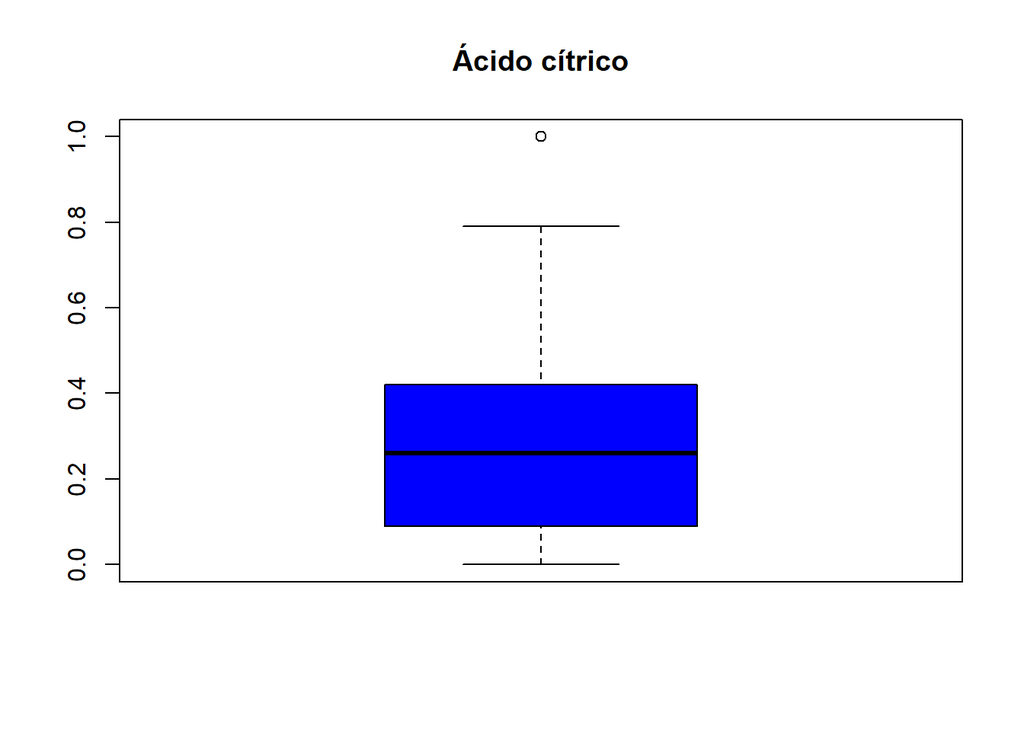

```r
#Boxplot para obtener los valores extremos
boxplot(variables$citric.acid,main="Ácido cítrico",col="blue")
```

```r
boxplot.stats(variables$citric.acid)$out
```

```
## [1] 1
```

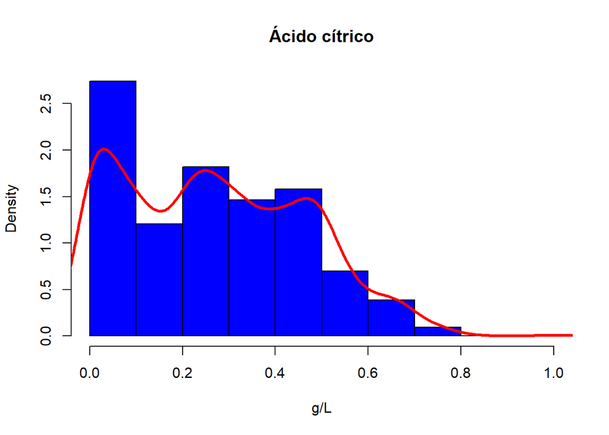

```r
#Diagrama de densidad para observar la distribución
den.cit<-density(variables$citric.acid)
hist(variables$citric.acid, main="Ácido cítrico", col="blue", freq = FALSE, xlab="g/L")
lines(den.cit,col="red",lwd=3)
```

Solo encontramos un valor (g/L) de ácido cítrico que se podría considerar como extremo. Según la página relacionada en el link (parte inicial del enunciado), el ácido cítrico se puede encontrar hasta concentraciones de 1 g/L, por lo cual no es un valor erroneo que podemos incluir en la estadística, ya que al ser solo uno no afectará. En cuanto a la distribución, no corresponde a una distribución normal, pero sus valores se encuentran todos dentro de lo esperado (0-1 g/L).

### SULFATOS

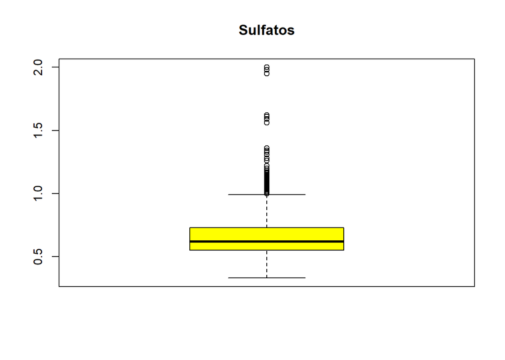

```r
#Boxplot para obtener los valores extremos
boxplot(variables$sulphates,main="Sulfatos",col="yellow")
```

```r
boxplot.stats(variables$sulphates)$out
```

```
##  [1] 1.56 1.28 1.08 1.20 1.12 1.28 1.14 1.95 1.22 1.95 1.98 1.31 2.00 1.08 1.59
## [16] 1.02 1.03 1.61 1.09 1.26 1.08 1.00 1.36 1.18 1.13 1.04 1.11 1.13 1.07 1.06
## [31] 1.06 1.05 1.06 1.04 1.05 1.02 1.14 1.02 1.36 1.36 1.05 1.17 1.62 1.06 1.18
## [46] 1.07 1.34 1.16 1.10 1.15 1.17 1.17 1.33 1.18 1.17 1.03 1.17 1.10 1.01
```

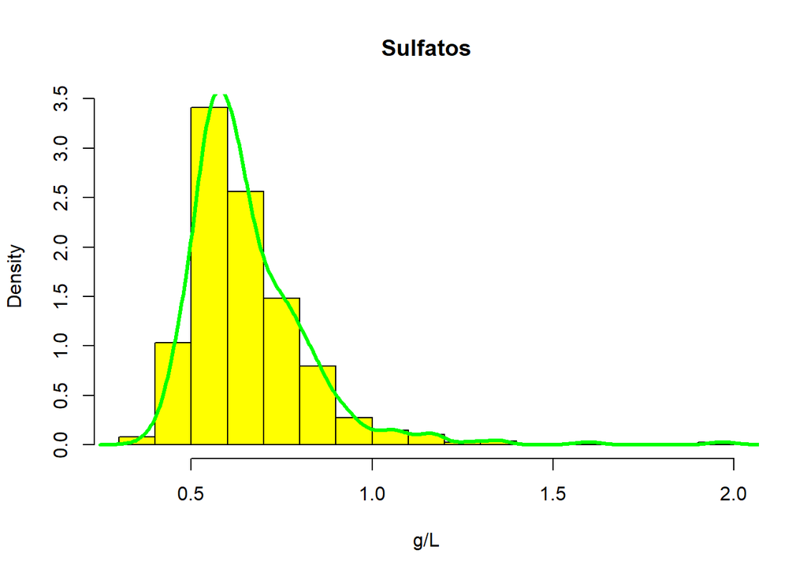

```r
#Diagrama de densidad para observar la distribución
den.sulf<-density(variables$sulphates)
hist(variables$sulphates, main="Sulfatos", col="yellow", freq = FALSE, xlab="g/L")
lines(den.sulf,col="green",lwd=3)
```

```r
#Observamos los cuantiles
x<-quantile(variables$sulphates)
x
```

```
##   0%  25%  50%  75% 100%
## 0.33 0.55 0.62 0.73 2.00
```

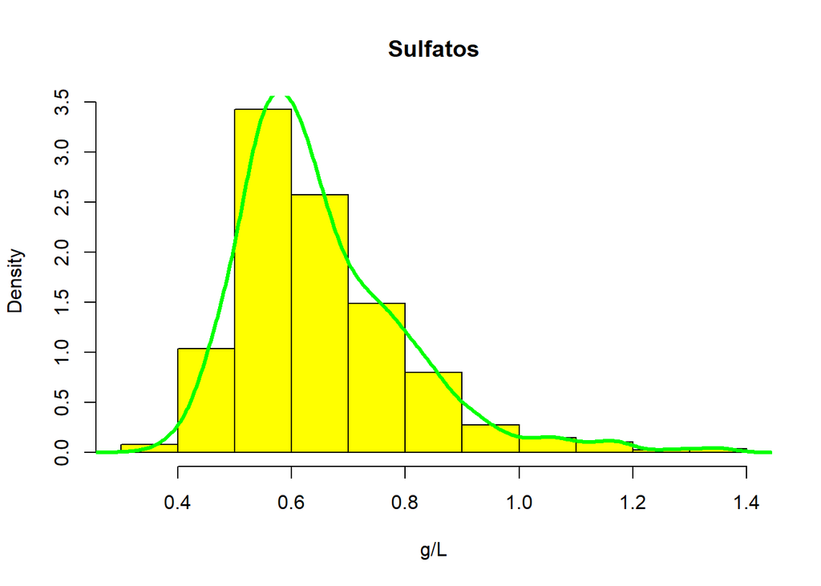

```r
#Eliminamos los outliers superiores a la mitad del ultimo cuantil y creamos un nuevo dataset con estos datos
redwine$quality[redwine$sulphates>(x[5]+x[4])/2]<-NA
redwine$sulphates[redwine$sulphates>(x[5]+x[4])/2]<-NA
data.sulfatos<-redwine[c(10,12)]
data.sulfatos<-data.sulfatos[!is.na(data.sulfatos$quality),]

#Diagrama sin outliers
den.sulf<-density(data.sulfatos$sulphates)
hist(data.sulfatos$sulphates, main="Sulfatos", col="yellow", freq = FALSE, xlab="g/L")
lines(den.sulf,col="green",lwd=3)
```

```r
#Número de outliers eliminados
sum(is.na(redwine$sulphates))
```

```
## [1] 8
```

En este caso nos encontrabamos con una gran presencia de valores extremos que si podría afectar a la estadística. Por tanto, se eliminan los que tienen valores superiores a la mitad del último percentil. De esta forma reducimos la influencia de los valores extremos, pero a su vez también los tenemos en cuenta, ya que las puntuaciones son opiniones personales y vinos con una mayor cantidad de concentración de sulfato podrían entrar dentro de los gustos de un tipo de público. Se eliminan 8 outliers correspondientes a los casos más extremos.

### ALCOHOL

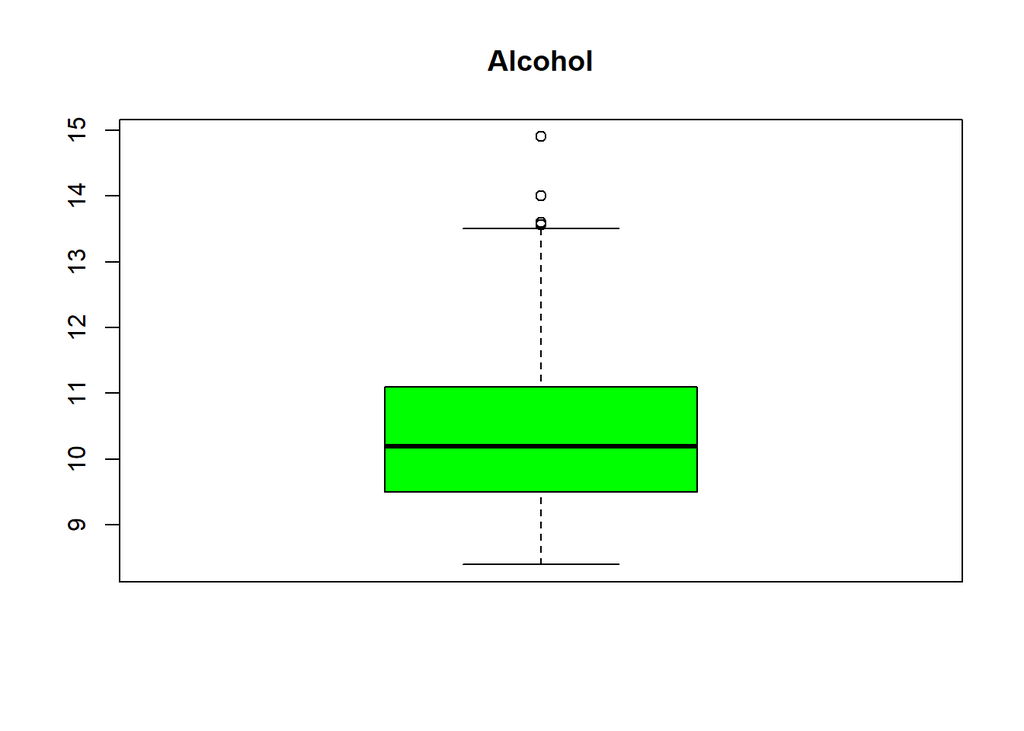

```r
#Boxplot para obtener los valores extremos
boxplot(variables$alcohol,main="Alcohol",col="green")
```

```r
boxplot.stats(variables$alcohol)$out
```

```
##  [1] 14.00000 14.00000 14.00000 14.00000 14.90000 14.00000 13.60000 13.60000
##  [9] 13.60000 14.00000 14.00000 13.56667 13.60000
```

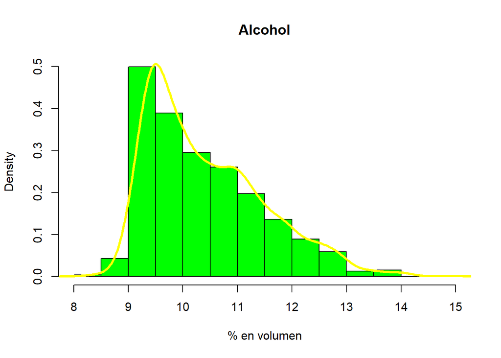

```r
#Diagrama de densidad para observar la distribución
den.al<-density(variables$alcohol)
hist(variables$alcohol, main="Alcohol", col="green", freq = FALSE, xlab="% en volumen")
lines(den.al,col="yellow",lwd=3)
```

En el caso del alcohol tenemos muy pocos valores extremos, por lo que podemos incluirlos, ya que tampoco son valores incoherentes.

# 4. ANÁLISIS DE DATOS

## 4.1 Selección de los datos y planificación de análisis

Dividiremos el análisis en tres partes sobre las variables que anteriormente hemos seleccionado. El objetivo y la respuesta a contestar es el tratar de aclarar que tipo de vinos son aquellos con la mayor calidad. Para ello analizaremos esta variable, la calidad, frente a la composición química de los vinos, concretamente, la acidez volátil, el ácido cítrico, los sulfatos y el alcohol. Los análisis a realizar son:

1. Regresión lineal simple. Trataremos de ajustar a la ecuación de una recta los datos de la calidad en función de los componentes químicos del vino. La pendiente nos dirá si debemos aumentar o reducir dicho componente para mejorar su calidad. Veremos la realineación que hay entre las diferentes variables que tenemos y la puntuación que se le hace a los vinos.Para ello haremos una regresión lineal con el fin de observar los gustos de la gente.
2. Intervalos de confianza. Calcularemos la media y los intervalos de confianza de nuestras variables para poder realizar resoluciones de contrastes de hipótesis bilaterales al 95% de confianza. Preguntas del estilo de ¿Puede ser la media de la calidad de una muestra 8?.
3. Arbol de decisión: Se implementa un modelo supervisado de clasificación de tipo C50, con el fin de identificar las propiedades de las variables seleccionadas que son características de los vinos de alta, media y baja calidad, de acuerdo a la calificación de las diferentes muestras de vino, las cuales se encuentran agrupadas en la variable QUALITY.

### 4.2.1 Regresión lineal simple (variable dependiente calidad)

Haremos las rectas de regresión de las diferentes variables frente a la variable dependiente calidad. De esta forma obtenemos un primer modelo que nos permite obtener la calidad a partir del resto de variables.

Para saber si nuestro modelo es viable primero haremos un gráfico para analizar los valores ajustados frente a los residuos. En este gráfico se representan en el eje de ordenadas el valor de los residuos y en el de abcisas los valores ajustados, de forma que si el modelo es bueno no se debería apreciar ninguna estructura y los valores serían cercanos al eje de abcisas.

Por último con un gráfico QQ podemos ver el efectos de los valores atípicos.

```r
#LIBRERIAS PARA LA REPRESENTACIÓN
library(ggplot2)
```

#### ACIDEZ VOLATIL

```r
#AJUSTE DE LOS DATOS A LA ECUACIÓN y=ax+b
lineal<-lm(calidad$quality~volatile.acidity,data=variables)
summary(lineal)
```

```
##
## Call:
## lm(formula = calidad$quality ~ volatile.acidity, data = variables)
##
## Residuals:
##      Min       1Q   Median       3Q      Max
## -2.79071 -0.54411 -0.00687  0.47350  2.93148
##
## Coefficients:
##                  Estimate Std. Error t value Pr(>|t|)
## (Intercept)       6.56575    0.05791  113.39   <2e-16 ***
## volatile.acidity -1.76144    0.10389  -16.95   <2e-16 ***
## ---
## Signif. codes:  0 '***' 0.001 '**' 0.01 '*' 0.05 '.' 0.1 ' ' 1
##
## Residual standard error: 0.7437 on 1597 degrees of freedom
## Multiple R-squared:  0.1525, Adjusted R-squared:  0.152
## F-statistic: 287.4 on 1 and 1597 DF,  p-value: < 2.2e-16
```

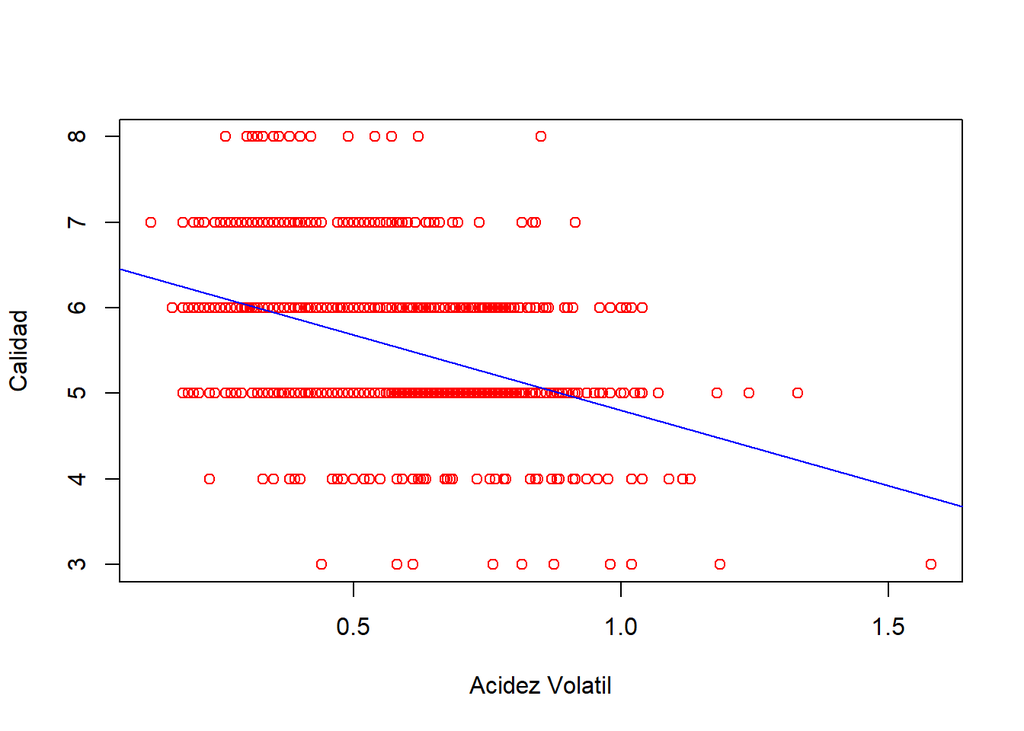

```r
#REPRESENTACIÓN GRÁFICA
plot(variables$volatile.acidity,calidad$quality, xlab = "Acidez Volatil", ylab = "Calidad", col="red")
#RECTA DE REGRESIÓN
abline(lineal, col="blue")
```

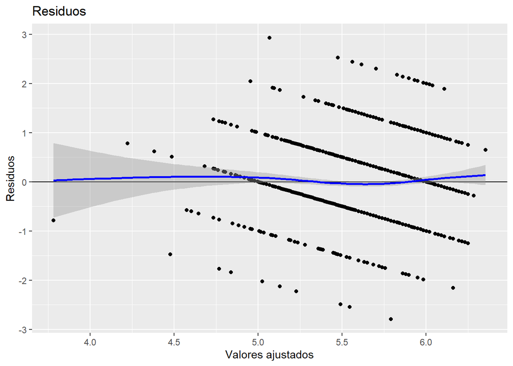

```r
#ANÁLISIS POR RESIDUOS
ggplot(data=variables, aes(lineal$fitted.values,lineal$residuals)) + geom_point() + geom_hline(yintercept = 0) + geom_smooth(color = "blue") + labs(title = "Residuos", x="Valores ajustados", y="Residuos")
```

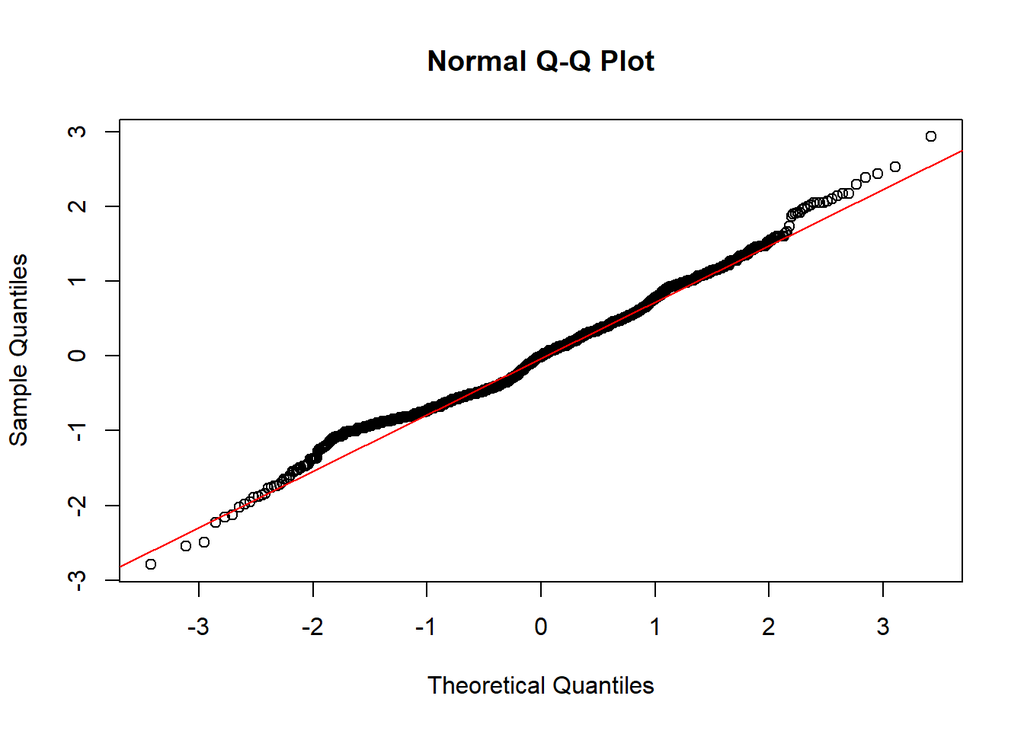

```r
#FUNCION QQNORM PARA REPRESENTAR EL GRÁFICO QUANTIL QUANTIL
qqnorm(lineal$residuals)
#LINEA DE TENDENCIA
qqline(lineal$residuals, col="red")
```

La recta se ajusta a los siguientes valores: y = -1.76144x + 6.56575

En el análisis por residuos vemos que los datos presentan una estructura definida, lo cual nos indica que el modelo lineal no se ajusta bien a los datos. Tambien podemos observar este detalle con el valor de R cuadrado, que es de 0.1525, muy bajo.

Vemos que el el gráfico QQ que tenemos valores atípicos y que estos, cuanto más se alejan de la normal, más desajustan los datos. En los primeros cuantiles si se observa normalidad.

#### ÁCIDO CÍTRICO

```r
#AJUSTE DE LOS DATOS A LA ECUACIÓN y=ax+b
lineal<-lm(calidad$quality~citric.acid,data=variables)
summary(lineal)
```

```
##
## Call:
## lm(formula = calidad$quality ~ citric.acid, data = variables)
##
## Residuals:
##     Min      1Q  Median      3Q     Max
## -3.0011 -0.5976  0.1021  0.5057  2.5901
##
## Coefficients:
##             Estimate Std. Error t value Pr(>|t|)
## (Intercept)  5.38172    0.03372 159.610   <2e-16 ***
## citric.acid  0.93845    0.10104   9.288   <2e-16 ***
## ---
## Signif. codes:  0 '***' 0.001 '**' 0.01 '*' 0.05 '.' 0.1 ' ' 1
##
## Residual standard error: 0.7869 on 1597 degrees of freedom
## Multiple R-squared:  0.05124,    Adjusted R-squared:  0.05065
## F-statistic: 86.26 on 1 and 1597 DF,  p-value: < 2.2e-16
```

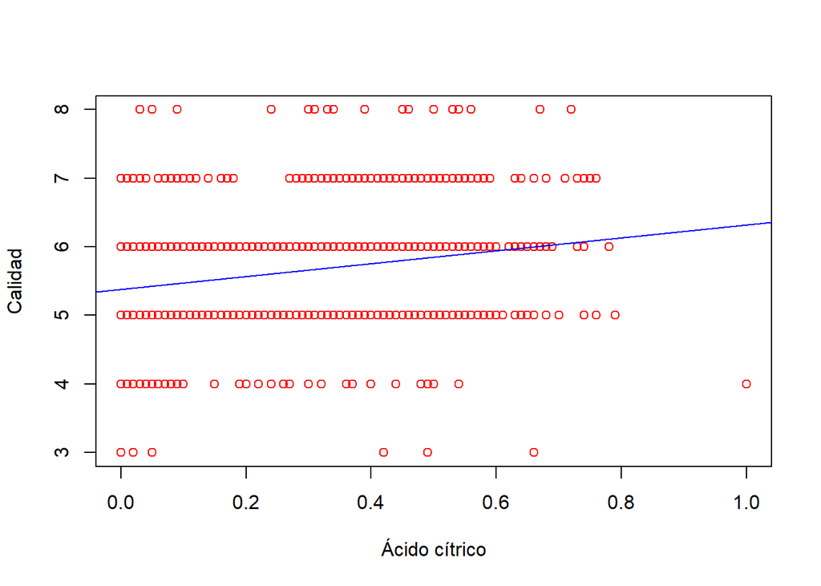

```r
#REPRESENTACIÓN GRÁFICA
plot(variables$citric.acid,calidad$quality, xlab = "Ácido cítrico", ylab = "Calidad", col="red")
#RECTA DE REGRESIÓN
abline(lineal, col="blue")
```

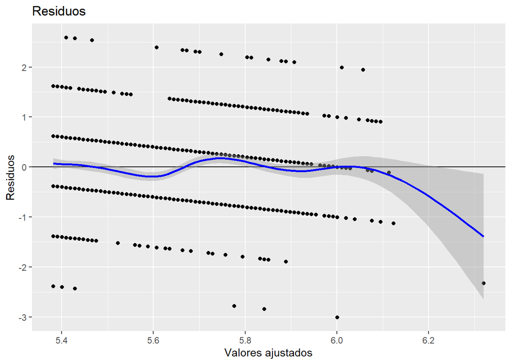

```r
#ANÁLISIS POR RESIDUOS
ggplot(data=variables, aes(lineal$fitted.values,lineal$residuals)) + geom_point() + geom_hline(yintercept = 0) + geom_smooth(color = "blue") + labs(title = "Residuos", x="Valores ajustados", y="Residuos")
```

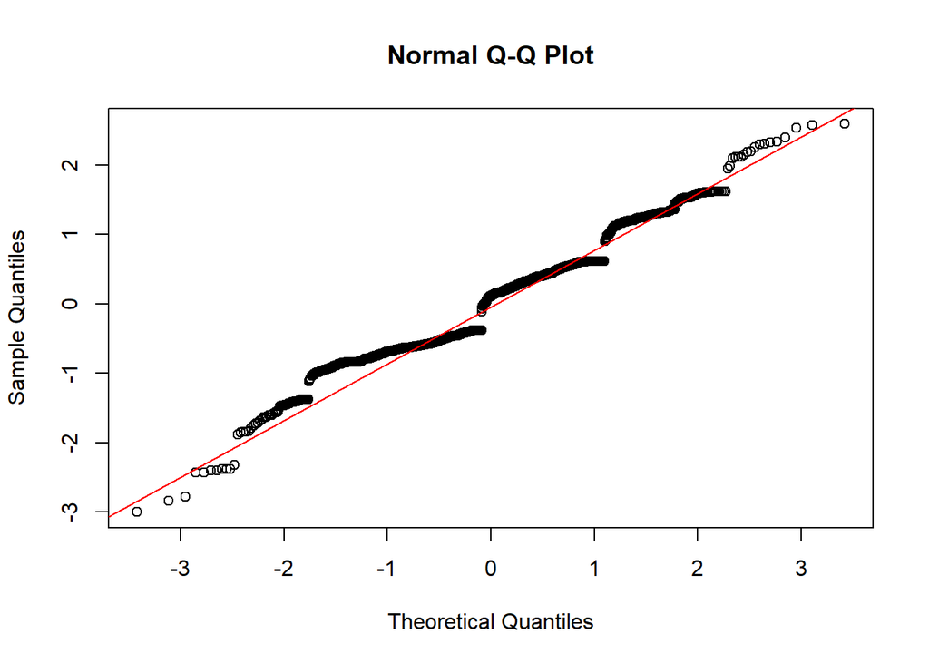

```r
#FUNCION QQNORM PARA REPRESENTAR EL GRÁFICO QUANTIL QUANTIL
qqnorm(lineal$residuals)
#LINEA DE TENDENCIA
qqline(lineal$residuals, col="red")
```

La recta se ajusta a los siguientes valores: y = 0.93845x + 5.38172

En el análisis por residuos vemos que los datos presentan una estructura definida, lo cual nos indica que el modelo lineal no se ajusta bien a los datos de la misma forma que podemos ver el efecto de algunos valores atípicos. Tambien podemos observar este detalle con el valor de R cuadrado, que es de 0.05065, practicamente cero.

Vemos que el el gráfico QQ no se ajusta bien en ningún cuantil, por lo que indica que la variable no es normal.

#### SULFATOS

```r
#Nuevo dataset para la representacion

#AJUSTE DE LOS DATOS A LA ECUACIÓN y=ax+b
lineal<-lm(quality~sulphates,data=data.sulfatos)
summary(lineal)
```

```
##
## Call:
## lm(formula = quality ~ sulphates, data = data.sulfatos)
##
## Residuals:
##      Min       1Q   Median       3Q      Max
## -2.98046 -0.51831  0.01954  0.46519  2.39917
##
## Coefficients:
##             Estimate Std. Error t value Pr(>|t|)
## (Intercept)  4.56099    0.08649   52.74   <2e-16 ***
## sulphates    1.65055    0.12921   12.77   <2e-16 ***
## ---
## Signif. codes:  0 '***' 0.001 '**' 0.01 '*' 0.05 '.' 0.1 ' ' 1
##
## Residual standard error: 0.7695 on 1589 degrees of freedom
## Multiple R-squared:  0.09313,    Adjusted R-squared:  0.09256
## F-statistic: 163.2 on 1 and 1589 DF,  p-value: < 2.2e-16
```

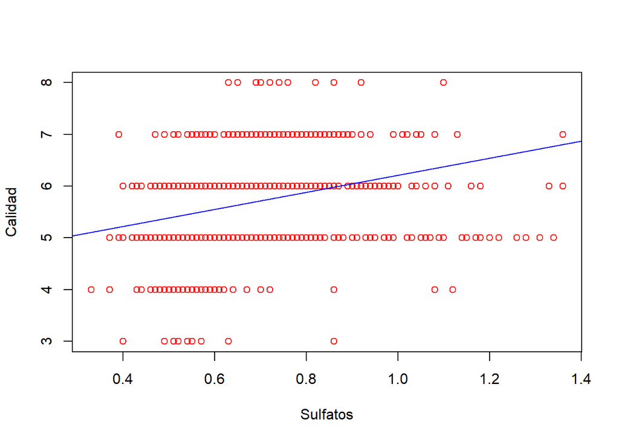

```r
#REPRESENTACIÓN GRÁFICA
plot(data.sulfatos$sulphates,data.sulfatos$quality, xlab = "Sulfatos", ylab = "Calidad", col="red")
#RECTA DE REGRESIÓN
abline(lineal, col="blue")
```

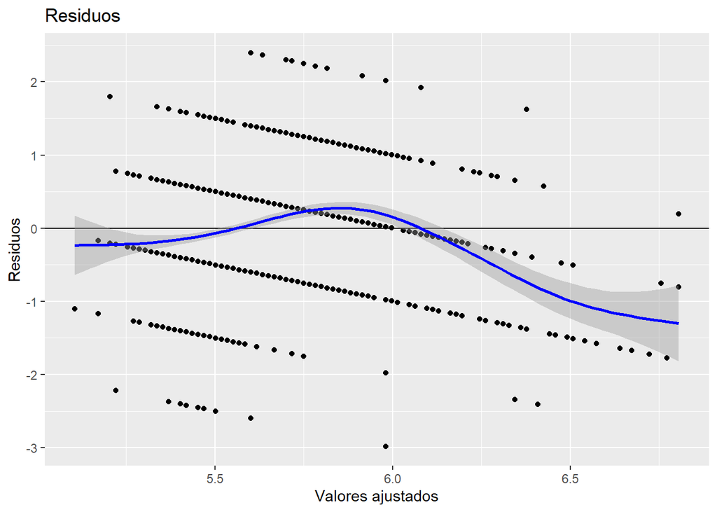

```r
#ANÁLISIS POR RESIDUOS
ggplot(data=data.sulfatos, aes(lineal$fitted.values,lineal$residuals)) + geom_point() + geom_hline(yintercept = 0) + geom_smooth(color = "blue") + labs(title = "Residuos", x="Valores ajustados", y="Residuos")
```

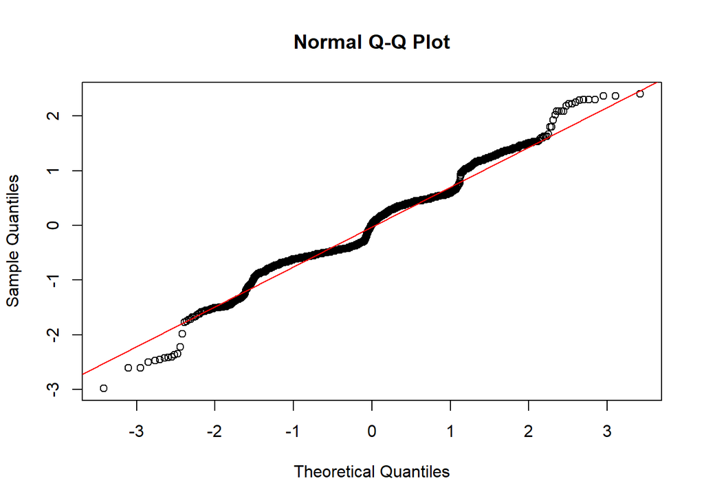

```r
#FUNCION QQNORM PARA REPRESENTAR EL GRÁFICO QUANTIL QUANTIL
qqnorm(lineal$residuals)
#LINEA DE TENDENCIA
qqline(lineal$residuals, col="red")
```

La recta se ajusta a los siguientes valores: y = 1.65055x + 4.56099

En el análisis por residuos vemos que los datos presentan una estructura definida, lo cual nos indica que el modelo lineal no se ajusta bien a los datos de la misma forma que podemos ver el efecto de algunos valores atípicos. Tambien podemos observar este detalle con el valor de R cuadrado, que es de 0.09256, practicamente cero.

Vemos que el el gráfico QQ no se ajusta bien en ningún cuantil, por lo que indica que la variable no es normal.

#### ALCOHOL

```r
#AJUSTE DE LOS DATOS A LA ECUACIÓN y=ax+b
lineal<-lm(calidad$quality~alcohol,data=variables)
summary(lineal)
```

```
##
## Call:
## lm(formula = calidad$quality ~ alcohol, data = variables)
##
## Residuals:
##     Min      1Q  Median      3Q     Max
## -2.8442 -0.4112 -0.1690  0.5166  2.5888
##
## Coefficients:
##             Estimate Std. Error t value Pr(>|t|)
## (Intercept)  1.87497    0.17471   10.73   <2e-16 ***
## alcohol      0.36084    0.01668   21.64   <2e-16 ***
## ---
## Signif. codes:  0 '***' 0.001 '**' 0.01 '*' 0.05 '.' 0.1 ' ' 1
##
## Residual standard error: 0.7104 on 1597 degrees of freedom
## Multiple R-squared:  0.2267, Adjusted R-squared:  0.2263
## F-statistic: 468.3 on 1 and 1597 DF,  p-value: < 2.2e-16
```

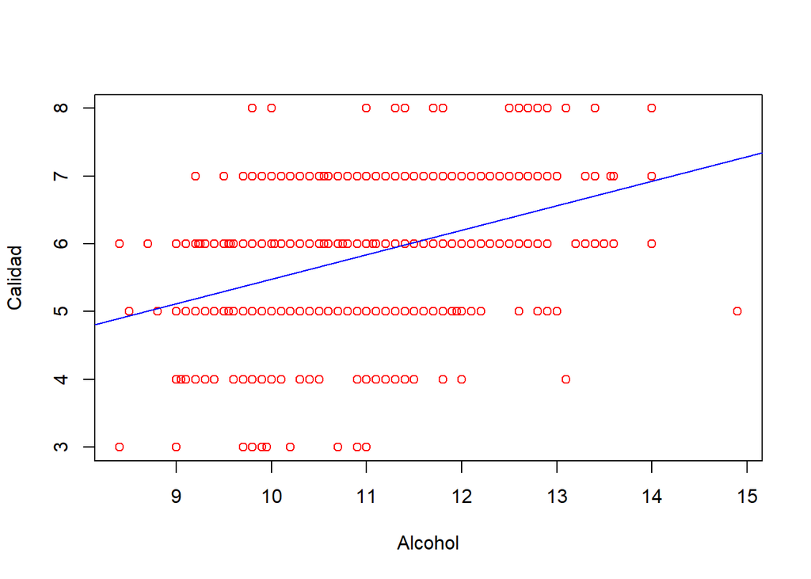

```r
#REPRESENTACIÓN GRÁFICA
plot(variables$alcohol,calidad$quality, xlab = "Alcohol", ylab = "Calidad", col="red")
#RECTA DE REGRESIÓN
abline(lineal, col="blue")
```

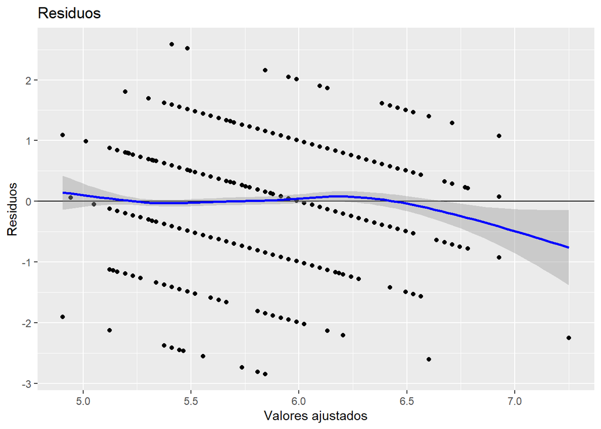

```r
#ANÁLISIS POR RESIDUOS
ggplot(data=variables, aes(lineal$fitted.values,lineal$residuals)) + geom_point() + geom_hline(yintercept = 0) + geom_smooth(color = "blue") + labs(title = "Residuos", x="Valores ajustados", y="Residuos")
```

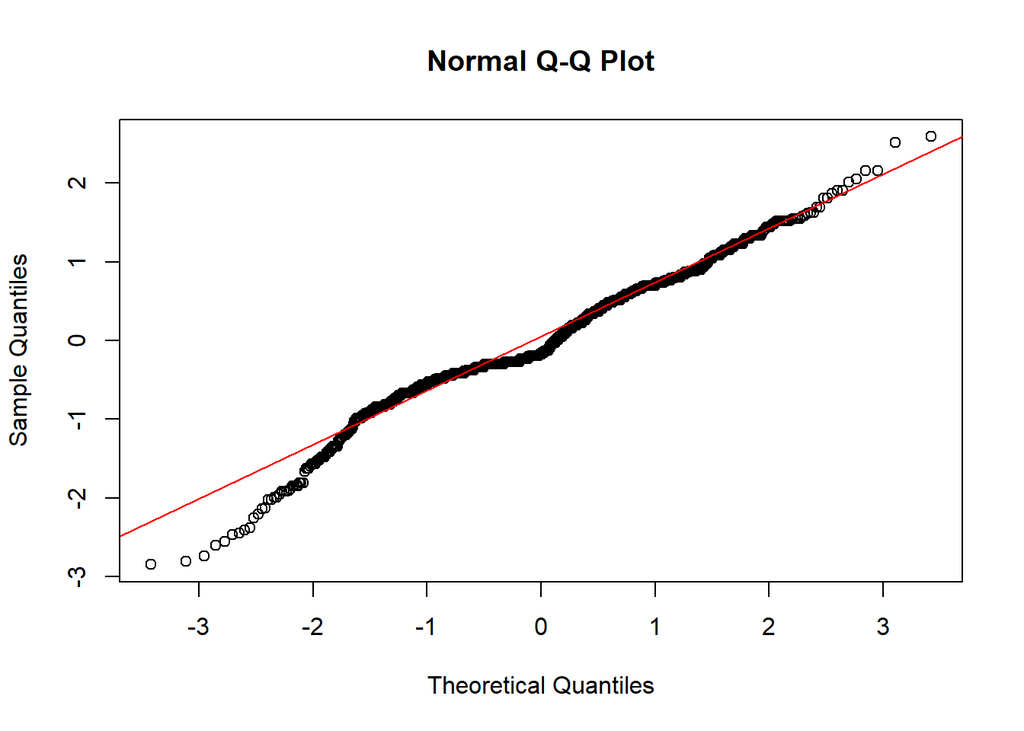

```r
#FUNCION QQNORM PARA REPRESENTAR EL GRÁFICO QUANTIL QUANTIL
qqnorm(lineal$residuals)
#LINEA DE TENDENCIA
qqline(lineal$residuals, col="red")
```

En el análisis por residuos vemos que los datos presentan una estructura definida, lo cual nos indica que el modelo lineal no se ajusta bien a los datos de la misma forma que podemos ver el efecto de algunos valores atípicos. Tambien podemos observar este detalle con el valor de R cuadrado, que es de 0.2263, muy baja, a pesar de ser la que mejor resultados da..

Vemos que el el gráfico QQ se ajusta bien en el primer y segundo cuantil pero no en el resto, donde volvemos a ver presencia de valores atípicos que desajustan mucho el modelo.